# Introduction to regression

04/30/2020

## Instructions:

Use the left and right arrow keys to navigate the presentation forward and backward respectively. You can also use the arrows at the bottom right of the screen to navigate with a mouse.

> FAIR USE ACT DISCLAIMER:  
> This site is for educational purposes only. This website may contain copyrighted material, the use of which has not been specifically authorized by the copyright holders. The material is made available on this website as a way to advance teaching, and copyright-protected materials are used to the extent necessary to make this class function in a distance learning environment. The Fair Use Copyright Disclaimer is under section 107 of the Copyright Act of 1976, allowance is made for “fair use” for purposes such as criticism, comment, news reporting, teaching, scholarship, education and research.

## Outline

- The following topics will be covered in this lecture:
  - Review of Correlation
  - Linear trends in data
  - Regression
  - Computing and graphing regression lines
  - Explained variation
  - Making predictions
  - Residuals

## Review of correlation

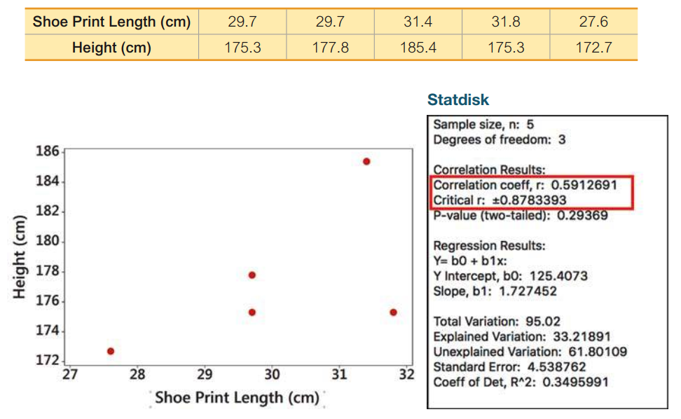

Courtesy of Mario Triola, *Essentials of Statistics*, 6th edition

- Recall in the last lecture, we studied the **linear correlation coefficient** as a way to **quantify a systematic, linear association between pairs of measurments** in a sample of data.
- In the case where:
1. the observations were collected by **simple random sampling**;
2. upon inspection with a scatter plot, there was **not a strong nonlinear pattern**; and
3. there were **no outliers in either of the \( x \) or \( y \) measurements**;
- We used the linear correlation coefficient, \[ \begin{align} r = \frac{\sum_{i=1}^n \left(z_{x_i} \times z_{y_i}\right)}{n-1} \end{align} \] to quantify the strength of this relationship.
- Values of **\( r \) close to \( 1 \)** could loosely be interpreted as **exhibiting a positive relationship between the variables \( x \) and \( y \)**.
- Values of **\( r \) close to \( -1 \)** could loosely be interpreted as **exhibiting a negative relationship between the variables \( x \) and \( y \)**.
- However, **\( r \) is a sample statistic** which we must **quantify the uncertainty** of due to **sampling error**;
- that is for the **population level correlation coefficient parameter \( \rho \)** we will usually **test the hypothesis**, \[ \begin{align} H_0: \rho =0 & & H_1 \rho \neq 0. \end{align} \]

### Review of correlation continued

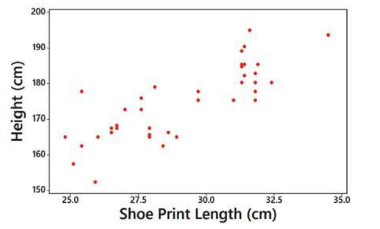

Courtesy of Mario Triola, *Essentials of Statistics*, 6th edition

- Recall that **critical values and p-values depend on the number of observations in the sample**.
- A **small number of measurements can easily exhibit a linear pattern** when there is **no correlation between the variables **(\( \rho=0 \))**** just by **random sampling error**;
- however, this is more difficult for a large number of measurements.
- As by the usual convention, if the p value for the hypothesis test is less than \( \alpha =0.05 \) we will rejet the null hypothesis with \( 5\% \) significance and claim that there exists some systematic linear relationship between the variables.
- **Note:** this systematic relationship does not mean one causes the other.
- **Correlation or anti-correlation** simply means that the **values tend to vary together or oppositely**;
- often, additional latent variables that are not measured can provide a better explantion of cause-and-effect.
- However, if we understand the purpose and limitations of correlation, this can be a powerful research tool to describe when certain measurements tend to vary together or oppositely as described above.
- A natural extension of this idea is if there is a linear trend, we can make a model for this trend in terms of a line.

## Regression

- Noting that there was correlation in height and shoe print length, we could say,

  > “On average, an increase in someone’s height usually goes along with an increase in their shoe print length (and vice versa).”
- A **regression line (or best fit line)** quantifies what this trend looks like.
- Recall the equation for a line, \[ y = {\color{red} a} +{\color{blue} b}x \]
- **The coefficient \( a \) is the intercept.**
- When the quantity \( x \) is zero, then \( y = {\color{red} a} \).
- **The coefficient \( b \) is the slope.**
- An increase of 1 unit of variable \( x \) corresponds to \( {\color{blue} b} \) units of increase in \( y \).
- In statitistics, we deal with random quantities that are subject to non-deterministic variation.
- In this case, a best fit line doesn’t mean that we have a direct input-output relationship as in the above equation.
- Rather, this should be viewed as, if we were to **average over the variation we see in the observations**, the **mean increase in \( y \) with a one unit increase in \( x \) would be **\( b \)****.
- This interpretation can then be used to predict the mean value of, e.g., the height, given some value of shoe print length.

### Requirements for regression

- Semi-formally, we will introduce regression as follows:
- Suppose that we have **\( n \) observations** in a **simple random sample with paired measurements \( (x,y) \)**.
- Suppose that when plotting \( y \) versus \( x \) in a scatter plot, we see **mostly a straight line pattern, and no signs of a nonlinear pattern**.
- For any fixed value \( x_i \), all associated values of \( y_{i,j} \) plotted above \( x_i \) should be roughly normally distributed, and the mean of the \( y_{i,j} \) should lie roughly on the straight line pattern.
- Suppose that for each fixed value \( x_i \), the standard deviation of all \( y_{i,j} \) lying above \( x_i \) should be approximately the same as for each other \( y_{k,j} \) lying above \( x_k \) where \( k\neq i \).
- Additonally, suppose there aren’t any extreme outliers in the observations.
- Under the loose conditions described above, we can effectively estimate a “best-fit” regression line \[ \hat{y} = b_0 + b_1 x; \]
- up to **some uncertainty**, due to **sampling error**, this **regression line estimates the mean value of the \( y_{i,j} \) distributed above \( x_i \) for any given value \( x_i \) in the scope of the model**.
- Actually, because **\( b_0 \) and \( b_1 \) are computed from samples**, these are **statistics** which are estimating **unknown popluation parameters** which describe the above relationship.

## The regression equation

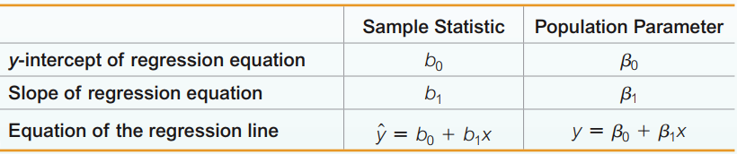

Courtesy of Mario Triola, *Essentials of Statistics*, 6th edition

- For the **regression line**, we are **assuming that there exist** actual **population parameters** that **describe the mean of the \( y \) values above \( x \) values**, as \[ y = {\color{#1b9e77} {\beta_0} }+ {\color{#1b9e77} {\beta_1} } x. \]
- The estimates \( b_0 \) and \( b_1 \) for the intercept and slope of this line are computed as \[ \begin{align} b_1 = r\times \frac{s_y}{s_x} & & b_0 = \overline{y} - b_1 \overline{x} \end{align} \]
- where:
1. **\( r \)** is the linear correlation coefficent which we discussed last lecture.
2. **\( s_x \)** is the sample standard deviation of the \( x \) values and **\( s_y \)** is the sample standard deviation of the \( y \) values;
3. **\( \overline{x} \)** is the sample mean of the \( x \) values and **\( \overline{y} \)** is the sample mean of the \( y \) values.
- Once again, this gives **sample-based estimates** for **population parameters**, so we will want to **quantify our uncertainty** about these values using our methods of **confidence intervals** and **hypothesis tests**.
- We will also want to **make sure the assumptions we discussed loosely** on the last slide **are accurate (for the most part)** – methods for checking these assumptions are called diagnostics.
- We note, if there are **large numbers of observations**, the **assumptions of normal distributions and equal standard deviations don’t have to hold exactly**, and we can still obtain reasonable results.
- However, we should **always be conscious of the effects of outliers**, because they **can dramatically change the way the regression line behaves**.

## Predictions

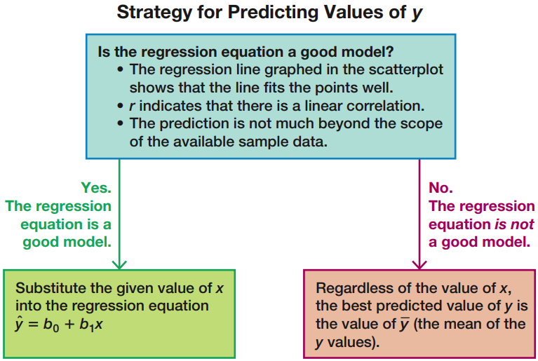

Courtesy of Mario Triola, *Essentials of Statistics*, 6th edition

- We saw how the **regression line** can give us a **numerical value for the expected value of the response variable \( y \) given some value \( x \)**.
- For a given choice of \( x_i \) this is given precisely by, \[ \hat{y}_i = b_0 + b_1 x_i, \] **but \( x_i \) does not have to be a value we have already observed**.
- This is what is meant by prediction with the regression function – **we can provide an expected value for a new case of \( x \) that has not been observed yet**.
- However, there are a number of **considerations and limitations of these predictions** which we will outline as follows.
- The first consideration should be if the regression equation is appropriate at all:
1. Visually, we should see that the **data follows the regression line well in a scatter plot**, and that it is **not strongly affected by outliers**.
2. The value of **\( r \)** should **reject the null hypothesis of \( H_0:\rho=0 \) with significance**.
- If this were **not the case**, we **cannot reject that the slope of the regression line should be equal to zero** as \( b_1 = r \times \frac{s_y}{s_x} \);
- if we can’t reject \( H_0:\rho=0 \), we **should just use \( \hat{y}= \overline{y} \) instead**.
3. The **value of \( x \) shouldn’t go beyond the scope of the observations** – **the predictions will become unreliable**.

### Predictions continued

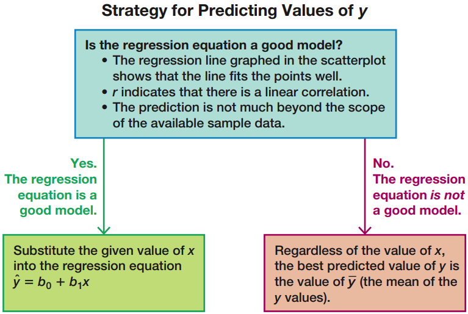

Courtesy of Mario Triola, *Essentials of Statistics*, 6th edition

- In the flow chart to the left, we can see the three conditions before – **suppose that these conditions are satisfied**.
- If these are satisfied, we can obtain the prediction directly as discussed before;
- let us suppose that \( x_i \) is some value of \( x \) for which we want to predict the expected value of \( y \).
- Then the **predicted value** is given by **substituting this value into the regression equation**, \[ \hat{y}_i = b_0 + b_1 x_i, \] rounded to the appropriate decimal place for the problem and scale of interest.
- However, **if any of the above conditions fail**, **we should instead use the mean of the \( y \) values directly as the prediction**, i.e., \( \hat{y}=\overline{y} \) as discussed earlier.
- In the quiz and the final exam, you should be able to examine a real data set for the above conditions, and find the appropriate prediction based on these conditions.
- Particularly, you should be able to identify which of the above conditions has failed, if any, and then compute the appropriate value for \( \hat{y} \).
- We will look at two such examples in the following in the body data in StatCrunch;
- however, even though we will only look at two examples you should be able to identify all of the conditions above and in different data sets included with the book online.

## Residuals

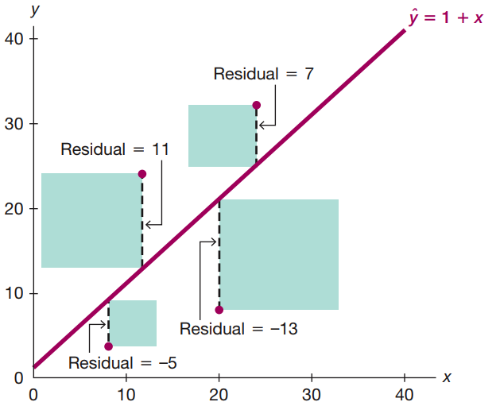

Courtesy of Mario Triola, *Essentials of Statistics*, 6th edition

- There are good reasons we might want to consider the **difference between an observed value and the value that the model predicts**.
- Suppose that \( x_i \) is actually some observed measurement paired with the observed value \( y_i \).
- In general, **we should not believe that \( y_i \) is actually equal to \[ \hat{y}_i = b_0 + b_1 x_i , \]** as there is random variation in every piece of sample data \( (x_i,y_i) \).
- Even though \( \hat{y}_i \) is our estimate for the expected value of \( y_i \), these observations are randomly distributed around the true expected value;
- therefore, there is generally a mismatch even if \( \hat{y} \) is a perfectly accurate estimate of the expected value.
- There is a special name for this **mismatch \( y_i - \hat{y}_i \)**, **the residual**.
- In the figure to the left, we can see a diagram of what a residual would look like in terms of the vertical lines.
- The **regression line is called a “best-fit” line** because it is actually the line that **minimizes the total of all squared residuals**.
- Concretely, this is a minimum distance line between the predicted and the observed values of \( y \) when written in terms of \( x \).
- This is generally a very desireable property for the predictions, but it is also a weakness when the data has extreme outliers, particularly in the \( x \) values…

## Outliers and influential points

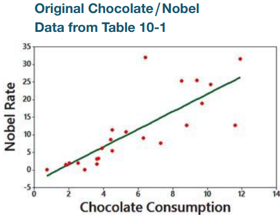

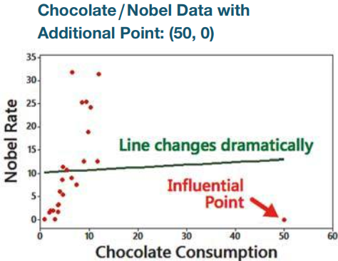

Courtesy of Mario Triola, *Essentials of Statistics*, 6th edition

- The regression line will try to fit the extreme outlier at the cost of other observations, when there is an extreme outlier in the \( x \) values.
- If there are **extreme outliers in the \( x \) values** that would otherwise lie off the regression line, **including such a point will dramatically change the fit**.
- Consider the plots to the left.
- In the left plot, we have the regression from the original Nobel/ Chocolate data where we have a reasonable fit to the data.
- In the right plot, the book’s author has included an influential point, in that it is extreme in the \( x \) values, and lies away from the original regression line.
- The regression line in the right plot has tried to minimize the squared residuals for all observations, but has placed special importance on this point at the cost of the others.
- This one of the main resons we need to be conscious of outlier points in the data, and to determine if these measurements are truthful or erroneous.
- Their presence can dramatically change our understanding of the relationship between \( x \) and \( y \), and the predictions we would obtain therenin.

## Residual plots

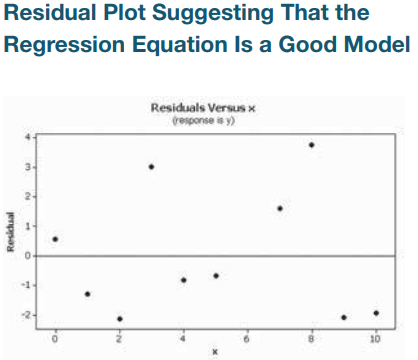

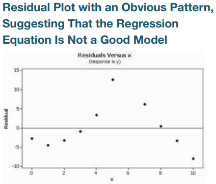

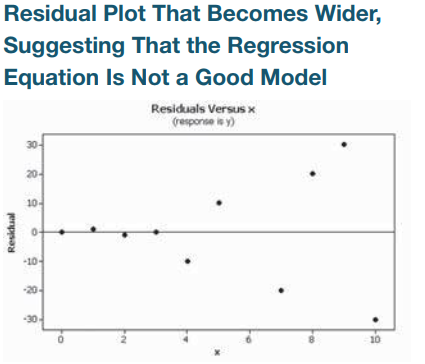

Courtesy of Mario Triola, *Essentials of Statistics*, 6th edition

- When performing regression in practice, one of the most important aspects is to verify if the assumptions have not held.
- This is most typically performed by plotting the residuals above the \( x \) value as in the above figures.
- Particularly, the residuals should just look like white-noise, with no particular pattern or structure.
- On the left, this is a **good case**, where there **isn’t any particular stucture**.
- In the middle, there is a **nonlinear structure** making the model **not a good fit**.
- On the right, the **residuals widen as we increase \( x \)**, meaning that the **equal standard deviation assumptionno longer holds**.
- This is just a quick preview of the kinds of ideas you would see in a future statistical modelling class, but will not be on the exams.